# Introduction to Text Analysis

MIT Political Methodology Lab Workshop Series 2021

Andy Halterman and Aidan Milliff

2 April 2021

# Text Analysis in `R`

Better off in Python for many things, but lots can be done in R.

## The Research Question

The “research question” in this demo is not a causal/descriptive question about politics *per se*, but it is plausibly a task you would have to do in order to start answering questions about politics. Lots of text analysis in social science is exactly this: tasks you have to do to transform, augment, or simplify text data into a state where you can start to ask and answer substantive political science questions.

We have a `.csv` of ~7,500 tweets, which are nominally about disasters of some type. We now at a pretty common starting point for text analysis. We have used Twitter’s new free [academic API](https://developer.twitter.com/en/solutions/academic-research) to get a bunch of data that we think pertain to a research question, but our initial process of gathering probably wasn’t as precise as we want. One issue we know our data have is metaphors and hyperbole. We want to identify people who are talking about *real* disasters, not disasters like a laptop crashing or calamities like spilling coffee on yourself. Text analysis tools can help with this.

## The Tools

We’re going to use three different tools to process and analyze the same text. With each, we’re pursuing the nominal “goal” of separating out the tweets that are about actual disasters.

### Sentiment Analysis (Supervised)

### Topic Modeling (Unsupervised)

### Logit Classification (Supervised)

## The Data

Our dataframe contains 7,613 unique tweets. For each tweet, we have a unique ID, the text, and a binary indicator (`target`) which takes a value of 1 if the tweet is about a real “disaster”, and a zero otherwise. Some tweets also have a location. Many have a “keyword.”

```r
# Load necessary packages

if (!require(tidyverse)) install.packages('tidyverse'); suppressMessages(library(tidyverse))# loads ggplot2, tibble, tidyr, readr, purr, dplyr, stringr, forcats
if (!require(tidytext)) install.packages('tidytext'); suppressMessages(library(tidytext)) # Our sentiment analysis package
if (!require(textdata)) install.packages('textdata'); suppressMessages(library(textdata)) # Provides our sentiment analysis dictionary
if (!require(stm)) install.packages('stm'); suppressMessages(library(stm)) # Structural topic model package
if (!require(tm)) install.packages('tm'); suppressMessages(library(tm)) # Another topic model package (for data cleaning)
if (!require(glmnet)) install.packages('glmnet'); suppressMessages(library(glmnet)) # Our logit classifier package
if (!require(textdata)) install.packages('textdata'); suppressMessages(library(textdata)) # Provides our sentiment analysis dictionary
# Load data
tweets <- read_csv("train.csv") # Make sure the text is read as characters, not factors.
summary(tweets)
```

```
       id          keyword            location             text               target
 Min.   :    1   Length:7613        Length:7613        Length:7613        Min.   :0.0000
 1st Qu.: 2734   Class :character   Class :character   Class :character   1st Qu.:0.0000
 Median : 5408   Mode  :character   Mode  :character   Mode  :character   Median :0.0000
 Mean   : 5442                                                            Mean   :0.4297
 3rd Qu.: 8146                                                            3rd Qu.:1.0000
 Max.   :10873                                                            Max.   :1.0000
```

```r
tweets %>% select(c(target,text)) %>% sample_n(10)
```

| target | text |
| --- | --- |
| 1 | @aelinrhee a group of mascara smeared girls rioting will be horrific I think |
| 0 | #Pandemonium.iso psp http://t.co/HbpNFOAwII |
| 0 | Man Who Buried Dog Alive Thought No One Would Find Her But She Was Rescued Just In Time http://t.co/SahQ5UOAHW |
| 1 | only had a car for not even a week and got in a fucking car accident .. Mfs can't fucking drive . |
| 0 | God's Kingdom (Heavenly Gov't) will rule over all people on the earth after Armageddon. http://t.co/8HGcBXUkz0 http://t.co/4kopkCyvTt |
| 0 | Trusting Iran to stop terrorism is like inviting an arsonist to join the fire brigade - Telegraph http://t.co/2Z2HTDjQZD |
| 1 | Understand that there are no fatalities as no one was trapped inside the wholesale market. 8 fire engines and 40 fire fighters on scene. |
| 1 | Watch This Airport Get Swallowed Up By A Sandstorm In Under A Minute http://t.co/7IJlZ6BcSP |
| 0 | HamptonRoadsFor.me US Navy Sidelines 3 Newest Subs - http://t.co/9QNQ45Zduw http://t.co/dhyLJllRHL |
| 0 | Uribe just annihilated that baseball. #Mets |

# Sentiment Analysis

There are a lot of packages to do sentiment analysis of different types. We are using `tidytext`, which is a popular package for exploring text data that, as the name suggests, is built to work well with the `tidyverse`.

Like most common sentiment analysis approaches, `tidytext` approaches a document as a combination of it’s constituent words, and the document’s sentiment as a combination of the sentiments of each word it contains—often just a running total of positive and negative words. To measure the sentiments of individual words, `tidytext` uses dictionaries, which assign positive/negative sentiment scores to individual words. Dictionary-based methods can be used for a bunch of things besides sentiment, so the code here can be repurposed to measure all sorts of other things that are captured in custom or off-the-shelf dictionaries.

The first step for sentiment analysis is converting our documents (tweets) into series of tokens (words or $n$-grams) that can get their own sentiment scores. We will use unigrams/single words because the sentiment dictionaries use unigrams as well. `tidytext` uses the same “data grammar” as the rest of the tidyverse, so each token will get its own row, and the columns will include attributes like the document to which it belongs.

```r
tidy_tweets <- tweets %>%
  unnest_tokens(token, # the name of the destination column
                text, # the name of the source column
                to_lower= F, # lowercasing, might drop URLS from tweets
                token = "tweets") # by-word tokenization, but preserves usernames, hashtags, urls that would get dropped with default tokenization
dim(tidy_tweets)
```

```
[1] 111682      5
```

```r
head(tidy_tweets, 20)
```

| id | keyword | location | target | token |
| --- | --- | --- | --- | --- |
| 1 | NA | NA | 1 | Our |
| 1 | NA | NA | 1 | Deeds |
| 1 | NA | NA | 1 | are |
| 1 | NA | NA | 1 | the |
| 1 | NA | NA | 1 | Reason |
| 1 | NA | NA | 1 | of |
| 1 | NA | NA | 1 | this |
| 1 | NA | NA | 1 | #earthquake |
| 1 | NA | NA | 1 | May |
| 1 | NA | NA | 1 | ALLAH |

[output cut: 10 more lines]

Now it’s time to pick a dictionary that matches tokens with sentiments. There are many options that can be called from `tidytext` with the `get_sentiments()` function. We’ll start with the `NRC` dictionary by [Mohammad and Tunney](http://saifmohammad.com/WebPages/%60NRC%60-Emotion-Lexicon.htm). Let’s first download the dictionary and look at what it provides.

```r
get_sentiments("nrc")
```

| word | sentiment |
| --- | --- |
| abacus | trust |
| abandon | fear |
| abandon | negative |
| abandon | sadness |
| abandoned | anger |
| abandoned | fear |
| abandoned | negative |
| abandoned | sadness |
| abandonment | anger |
| abandonment | fear |

[output cut: 990 more lines]

The `NRC` dictionary has a lot more than positive and negative! It also associates words with particular emotions, which we may want to do. In this case, though, we’re just going to use the “positive” and “negative” sentiments in the dictionary.

To apply the dictionary to our tweet data, we’re just going to do a big “inner join.” This will leave us with a `tbl` with a row for each positive and negative token that appears in a tweet, at which point we just need to calculate some tweet-level statistics.

```r
tweets_nrc <- tidy_tweets %>%
  inner_join(get_sentiments("nrc") %>%
               filter(sentiment %in% c("positive", "negative")),
             by = c("token" = "word"))
```

Before we analyze our sentiment scores, let’s take a look at what happened.

```r
dim(tweets_nrc)
```

```
[1] 7817    6
```

```r
head(tweets_nrc, 20)
```

| id | keyword | location | target | token | sentiment |
| --- | --- | --- | --- | --- | --- |
| 5 | NA | NA | 1 | shelter | positive |
| 5 | NA | NA | 1 | evacuation | negative |
| 5 | NA | NA | 1 | shelter | positive |
| 6 | NA | NA | 1 | evacuation | negative |
| 13 | NA | NA | 1 | top | positive |
| 14 | NA | NA | 1 | emergency | negative |
| 14 | NA | NA | 1 | evacuation | negative |
| 14 | NA | NA | 1 | building | positive |
| 15 | NA | NA | 1 | afraid | negative |
| 18 | NA | NA | 1 | lost | negative |

[output cut: 10 more lines]

Notice how much smaller the “scored” data frame is? Only 7% of the tokens in `tidy_tweets` matched an entry in the `NRC` dictionary. And only 56% of the tweets are scored at all. For shorter documents like tweets, dictionaries just have a mechanically lower probability of giving you any measurement at all.

Whether or not the result is “better,” would another dictionary at least measure the sentiment in more tweets? Let’s try the `bing` lexicon by [Bing Liu et al.](https://www.cs.uic.edu/~liub/FBS/sentiment-analysis.html), another dictionary included in `tidytext` which scores more words than `NRC`.

```r
tweets_bing <- tidy_tweets %>%
  inner_join(get_sentiments("bing"),
             by = c("token" = "word"))
```

Alas, this only scores 53% of the tweets. Let’s use both anyway to see how they compare. Our goal is to calculate a “sentiment score” for each tweet, which is just going to be the count of positive tokens minus the count of negative tokens.

```r
# NRC
scores_nrc <- tweets_nrc %>%
  group_by(id) %>%
  pivot_wider(names_from = sentiment,
              values_from = token,
              values_fn = list(token = length),
              values_fill = 0) %>%
  mutate(sentiment = positive - negative)

# bing

scores_bing <- tweets_bing %>%
  group_by(id) %>%
  pivot_wider(names_from = sentiment,
              values_from = token,
              values_fn = list(token = length),
              values_fill = 0) %>%
  mutate(sentiment = positive - negative)
```

Before we actually look to see if sentiment has helped us identify “disaster” tweets, let’s just see how the different dictionaries compare to each other. We’ll look only at the tweets that were scored by both.

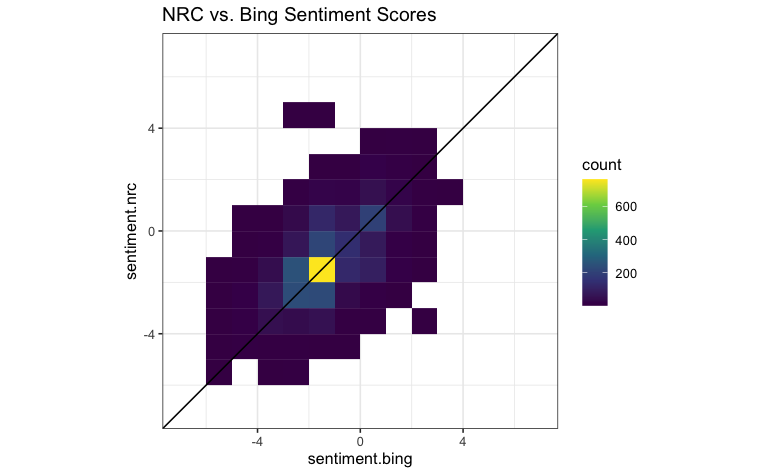

```r
scores_compare <- scores_nrc %>% select(c(id, positive, negative, sentiment, target)) %>% inner_join(scores_bing %>% select(c(id, positive, negative, sentiment, target)), by = "id", suffix = c(".nrc", ".bing"))


ggplot(scores_compare, aes(x = sentiment.bing, y = sentiment.nrc)) +
  geom_bin2d(bins = 14) +
  scale_fill_continuous(type = "viridis") +
  geom_abline(slope = 1) +
  coord_fixed() +
  xlim(c(-7,7)) +
  ylim(c(-7,7)) +
  theme_bw() +
  labs(title = "NRC vs. Bing Sentiment Scores")
```

```r
cor(scores_compare$sentiment.bing, scores_compare$sentiment.nrc)
```

```
[1] 0.5885745
```

The two scores are clearly positively correlated, though the correlation coefficient is only 0.589. The plot also suggests that the center of mass for sentiment scores in our tweet corpus is, intuitively, below zero. It would be puzzling if a corpus of tweets nominally about disasters was more positive than negative!

OK, on to our actual goal: does sentiment tell us much about the disaster content of the tweets? Let’s just start by comparing sentiment scores of tweets that are/not actually about disaster.

```
`fun.y` is deprecated. Use `fun` instead.
```

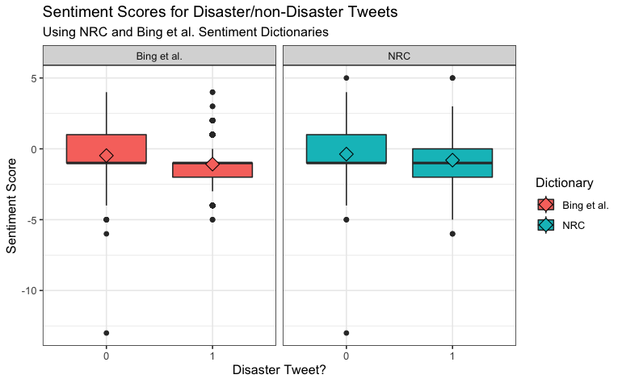

```r
plot <- bind_rows(scores_nrc %>% mutate(dict = "NRC"),
                  scores_bing %>% mutate(dict = "Bing et al."))
ggplot(plot, aes(x = factor(target), y = sentiment, fill = dict)) +
  geom_boxplot() +
  stat_summary(fun.y=mean, geom="point", shape=23, size=4) +
  facet_wrap(~dict) +
  theme_bw() +
  labs(title = "Sentiment Scores for Disaster/non-Disaster Tweets",
       subtitle = "Using NRC and Bing et al. Sentiment Dictionaries",
       fill= "Dictionary",
       y = "Sentiment Score",
       x = "Disaster Tweet?")
```

```r
NA
```

Plot looks pretty good! The “mass” of sentiment scores looks higher for the non-disaster tweets than for the actual disaster tweets. But is it really that good? The medians are quite close together even though the distributions are different. Let’s do some simple t-tests to be sure.

```r
t.test(scores_nrc$sentiment[which(scores_nrc$target == 1)],
       scores_nrc$sentiment[which(scores_nrc$target == 0)])
```

```
    Welch Two Sample t-test

data:  scores_nrc$sentiment[which(scores_nrc$target == 1)] and scores_nrc$sentiment[which(scores_nrc$target == 0)]
t = -10.655, df = 4130.1, p-value < 2.2e-16
alternative hypothesis: true difference in means is not equal to 0
95 percent confidence interval:
 -0.5051750 -0.3481599
sample estimates:
 mean of x  mean of y
-0.7988384 -0.3721710
```

```r
t.test(scores_bing$sentiment[which(scores_bing$target == 1)],
       scores_bing$sentiment[which(scores_bing$target == 0)])
```

```
    Welch Two Sample t-test

data:  scores_bing$sentiment[which(scores_bing$target == 1)] and scores_bing$sentiment[which(scores_bing$target == 0)]
t = -15.36, df = 3847.2, p-value < 2.2e-16
alternative hypothesis: true difference in means is not equal to 0
95 percent confidence interval:
 -0.6782348 -0.5246926
sample estimates:
 mean of x  mean of y
-1.0797619 -0.4782982
```

That looks good too. There’s a pretty convincing difference in means, but we’ve hardly got perfect separation. Why is that? Whether or not a tweet is actually about a disaster depends a lot on context. Sentiment scoring as we used it explicity ignores context. NRC, for example, would assign a positive value to the word “shelter” whether it occured in a tweet quoting Bob Dylan lyrics (“I’ll give ya shelter from the storm”), or a tweet about wildfires (“firefighters were forced to deploy their fire shelters”). That’s potentially a problem. Let’s just look at some extreme sentiment scores on our tweets as a little closing reminder about the limitations that come with dictionary methods. We’ll use NRC scores for this.

```r
scored_tweets <- tweets %>% inner_join(scores_nrc %>% select(c(id, sentiment)), by = "id")
positives <- scored_tweets %>% select(c(text, sentiment, target)) %>% filter(sentiment > quantile(sentiment,.9)) %>% sample_n(5)
negatives <- scored_tweets %>% select(c(text, sentiment, target)) %>% filter(sentiment < quantile(sentiment,.1)) %>% sample_n(5)

positives
```

| text | sentiment | target |
| --- | --- | --- |
| RT: Our_Mother_Mary: Short Reading\n\nApocalypse 21:1023 \n\nIn the spirit the angel took me to the top of an enormous high mountain and... \u0089Û_ | 3 | 0 |
| Set our hearts ablaze and every city was a gift And every skyline was like a kiss upon the lips @\u0089Û_ https://t.co/cYoMPZ1A0Z | 2 | 0 |
| C-130 specially modified to land in a stadium and rescue hostages in Iran in 1980 http://t.co/jkD7CTi2iW http://t.co/LAjN2n5e2d | 2 | 1 |
| @Karnythia my niece is gaining the ability to stand. I'm getting prepared for toddler apocalypse Armageddon | 3 | 0 |
| Detonation fashionable mountaineering electronic watch water-resistant couples leisure tab\u0089Û_ http://t.co/UCAwg59ulJ http://t.co/eNqDfbJUMP | 2 | 0 |

```r
negatives
```

| text | sentiment | target |
| --- | --- | --- |
| I am that girl on tv that sadly turns her music up to drown out the noise of her family fighting literally every day | -3 | 0 |
| @RobertONeill31 Getting hit by a foul ball while sitting there is hardly a freak accident. It's a war zone. | -4 | 0 |
| @yelllowheather controlled murder is fine. mass murder to a crowd of undeserving people isn't. case closed. | -3 | 1 |
| Nick Williams just hit another bomb. Just crushed it | -3 | 0 |
| kabwandi_: Breaking news! Unconfirmed! I just heard a loud bang nearby. in what appears to be a blast of wind from my neighbour's ass. | -3 | 0 |

# Topic Modeling

Ahhh the topic model. Invented when most of us were in elementary school, but re-popularized by an excellent implementation and user-friendly `R` package written by political scientists in the 2010s! Topic models are *unsupervised* models, which are useful for creating summaries (“low-dimensional representations”) of your text data. With few exceptions (c.f. ongoing work by Eshima, Imai, and Sasaki (!)) unsupervised models do not let you give input into *how* the model summarizes your text. The summaries are also kind of unstable. Here’s a very quick work-along for the Structural Topic Model (STM, Roberts, Stewart, and Tingley, 2018).

## Preparing the Data

Unlike dictionary based methods in which we could just do string matching, topic modeling requires that we start by getting our documents represented as vectors. The `stm` package makes this very easy. All you need to give it is a dataframe where one column is the texts and other colums are metadata/covariates. It converts the texts to a document-term matrix representation where each document is a row vector of length $v$ where $v$ is the size of the vocabulary, i.e. number of unique tokens in the whole corpus of documents. The $k^{th}$ element of the row vector takes a value of 0 if term $k$ does not appear in the document, a value of 1 if it appears once, and so on.

```r
processed <- textProcessor(tweets$text, metadata = cbind.data.frame(tweets$keyword, tweets$target))
```

```
Building corpus...
Converting to Lower Case...
Removing punctuation...
Removing stopwords...
Removing numbers...
Stemming...
Creating Output...
```

Check out the representation of our tweets in the format produced by the `textProcessor()` function from `stm`.

```r
tweets$text[1]
```

```
[1] "Our Deeds are the Reason of this #earthquake May ALLAH Forgive us all"
```

```r
rbind(processed$vocab[processed$documents$`1`[1,]],processed$documents$`1`)
```

```
     [,1]    [,2]   [,3]        [,4]     [,5]    [,6]
[1,] "allah" "deed" "earthquak" "forgiv" "may"   "reason"
[2,] "366"   "3008" "3588"      "4395"   "11925" "14202"
[3,] "1"     "1"    "1"         "1"      "1"     "1"
```

Any ideas why they look so different?

Let’s repeat the process with `tm` (the `textProcessor()` function is just a wrapper around these steps) to see how we get from the raw text to that vector.

```r
text <- Corpus(VectorSource(tweets$text)) # This just puts our texts in a nested list, basically
text[[1]][[1]]
```

```
[1] "Our Deeds are the Reason of this #earthquake May ALLAH Forgive us all"
```

```r
prep <- tm_map(text, content_transformer(tolower)) # puts everything in lowercase. This is a modeling choice that makes WOW and wow the same word.
```

```
transformation drops documents
```

```r
prep[[1]][[1]]
```

```
[1] "our deeds are the reason of this #earthquake may allah forgive us all"
```

```r
prep <- tm_map(prep, stripWhitespace) # gets rid of leading or trailing junk
```

```
transformation drops documents
```

```r
prep[[1]][[1]]
```

```
[1] "our deeds are the reason of this #earthquake may allah forgive us all"
```

```r
prep <- tm_map(prep, removePunctuation) # Drops punctuation. On twitter, this turns hashtags into plain old words
```

```
transformation drops documents
```

```r
prep[[1]][[1]]
```

```
[1] "our deeds are the reason of this earthquake may allah forgive us all"
```

```r
prep <- tm_map(prep, removeNumbers) # Similar to above
```

```
transformation drops documents
```

```r
prep <- tm_map(prep, removeWords, stopwords(kind = "en")) # Drops extremely common "nuisance" words. We can talk more about this.
```

```
transformation drops documents
```

```r
prep[[1]][[1]]
```

```
[1] " deeds   reason   earthquake may allah forgive us "
```

```r
prep <- tm_map(prep, stemDocument) # Trim words down to their "stems" to make words like forgiving, forgive, forgives, forgivness the same
```

```
transformation drops documents
```

```r
prep[[1]][[1]]
```

```
[1] "deed reason earthquak may allah forgiv us"
```

```r
dtm <- DocumentTermMatrix(prep) # Coerce stemmed documents into a DTM
as.matrix(dtm)[1:2,c(1:13)]
```

```
    Terms
Docs allah deed earthquak forgiv may reason canada fire forest near rong sask ask
   1     1    1         1      1   1      1      0    0      0    0    0    0   0
   2     0    0         0      0   0      0      1    1      1    1    1    1   0
```

Note that while the remaining stems appear in order in that DTM, the model won’t respect the order.

Next, STM asks for another pre-processing step before we can start fitting the model.

```r
out <- prepDocuments(processed$documents, processed$vocab, processed$meta)
```

```
Removing 13078 of 18136 terms (13078 of 70312 tokens) due to frequency
Removing 11 Documents with No Words
Your corpus now has 7602 documents, 5058 terms and 57234 tokens.
```

This single command does a lot of stuff! The main thing is it drops terms (and sometimes whole documents as a result) that appear super infrequently or super frequently. Neither are actually useful for the model.

## Fitting a Model

Now that the text is pre-processed, there are a few decisions we need to make to fit the model. We’re not going to go through them here, but the `stm` [vignette](https://cran.r-project.org/web/packages/stm/vignettes/stmVignette.pdf) is a good primer (see Sec. 3.4 especially), and these modeling decisions are important to understand if you want to use topic modeling.

Let’s “fit” a model. This model is on the faster end of STM fits, but still takes a while, so let’s just look at the syntax, and then load a model object that’s already provided.

```r
# mod <- stm(out$documents, # Documents from the prep function
           # out$vocab, # Vocab from same function
           # K=10) # Number of topics. Lots of ways to pick, including some empirical ways described in the package documentation.
                # We're ignoring prevalence covariates, which actually makes this just a correlated topic model, but this shows you how to do the steps at least.
# save(mod, file="stm.RData")
load("stm.RData")
```

## Labeling Topics

How do you analyze a topic model? It requires some work, and some decision-making that you want to document and prepare to justify See Grimmer and Stewart ([2013](https://www.cambridge.org/core/journals/political-analysis/article/text-as-data-the-promise-and-pitfalls-of-automatic-content-analysis-methods-for-political-texts/F7AAC8B2909441603FEB25C156448F20)) for more on the how and why of those decisions.

The first step is just to inspect the topics that our model yields for coherence and content. Remember, STM is identifying clusters of *words* that appear together, and hoping that because of the way human language works, the co-occurrence of words means those documents are communicating a particular idea, or topic. The topics are not guaranteed to be coherent. One very common mistake when analyzing a topic model is trusting that the model’s topics must mean *something* and then shoe-horning meaning onto an incoherent pile of words.

How should we figure out what (if anything) topics mean? We can start by just displaying the top words associated with each topic.

```r
labelTopics(mod)
```

```
Topic 1 Top Words:
     Highest Prob: fire, amp, home, california, collaps, first, think
     FREX: fire, amp, home, california, collaps, think, two
     Lift: answer, cnn, germ, lose, -alarm, å£bn, achimota
     Score: fire, amp, home, wildfir, california, raze, fedex
Topic 2 Top Words:
     Highest Prob: bomb, peopl, kill, video, news, day, love
     FREX: bomb, peopl, kill, video, day, love, train
     Lift: amongst, appropri, captain, falcon, fit, flew, gta
     Score: suicid, bomb, bomber, migrant, deton, kill, saudi
Topic 3 Top Words:
     Highest Prob: just, make, back, world, let, obliter, call
     FREX: make, back, world, let, obliter, call, collid
     Lift: join, abomin, adopt, alright, anna, applic, appoint
     Score: just, back, make, obliter, let, conclus, collid
Topic 4 Top Words:
     Highest Prob: get, emerg, time, bodi, still, know, watch
     FREX: get, emerg, time, know, watch, bag, death
     Lift: aint, altern, balanc, bid, campus, chase, coffe
     Score: get, bag, emerg, bodi, watch, cross, wreck
Topic 5 Top Words:
     Highest Prob: like, disast, year, fatal, famili, storm, live
     FREX: like, disast, year, fatal, famili, storm, live
     Lift: achiev, advertis, afraid, amirit, antioch, art, aveng
     Score: legionnair, like, declar, disast, obama, fatal, famili
Topic 6 Top Words:
     Highest Prob: one, can, build, say, see, come, scream
     FREX: one, can, build, say, see, come, scream
     Lift: abl, adjust, afghanistan, bargain, basic, bedroom, bleed
     Score: can, one, build, say, scream, see, come
Topic 7 Top Words:
     Highest Prob: burn, look, got, war, today, may, surviv
     FREX: burn, look, got, war, may, surviv, right
     Lift: deliv, drop, accident, actual, ahh, alp, anniversari
     Score: burn, look, got, costlier, refugio, spill, may
Topic 8 Top Words:
     Highest Prob: evacu, man, caus, feel, crash, fuck, realli
     FREX: evacu, man, caus, feel, fuck, realli, great
     Lift: alli, approach, beach, beard, bet, bird, bite
     Score: fuck, feel, evacu, man, china, caus, stock
Topic 9 Top Words:
     Highest Prob: via, flood, attack, nuclear, accid, help, near
     FREX: flood, nuclear, hostag, warn, issu, sever, thunderstorm
     Lift: -day, -foot, acut, aftershock, agenc, air, airlin
     Score: flood, via, miner, warn, sever, issu, thunderstorm
Topic 10 Top Words:
     Highest Prob: will, now, dont, polic, want, car, take
     FREX: will, now, dont, polic, want, car, take
     Lift: abus, arsenal, boot, co-found, dem, demand, drove
     Score: will, now, dont, reddit, polic, want, prebreak
```

The STM vignette describes the different weighting schemes that are used to produce the ``top stems.’’ I like FREX, becuase it weights words by their overall frequency, but also their exclusivity to the topic.

We’re now at another common stumbling block. Many topic model users scrutinize this output to decide whether the topics are coherent and what they mean. This is not recommended, because we’re still looking at individual words out of context, not the documents we are trying to understand. Best practice for labeling Topic Model topics involves reading the documents most strongly associated with each topic, and then using your own judgment to assign a “name” to the underlying topic that those documents are discussing. Doubleplusgood practice would be to save those ‘top documents’ and put them in an appendix so that readers and reviewers can look at the same information and decide for themselves whether they agree with your labeling. The `stm` package has a function that will help us.

```r
topdocs_n10 <- findThoughts(mod, texts = tweets$text[-out$docs.removed], n= 10)
print(topdocs_n10)
```

```
 Topic 1:
     #SigAlert: North &amp; Southbound 133 closed btwn 5 fwy and Irvine Blvd due to truck fire. CHP is detouring traffic.
    #SigAlert: North &amp; Southbound 133 closed btwn 5 fwy and Irvine Blvd due to truck fire. CHP is detouring traffic.
    RT alisonannyoung: EXCLUSIVE: FedEx no longer to transport research specimens of bioterror pathogens in wake of anthrax lab mishaps Û_
    FedEx to stop transporting bioterror germs after lab mishaps: FedEx has stopped transporting certain research ... http://t.co/y3dM9uLqxG
    Russian 'food crematoria' provoke outrage amid crisis famine memories - Yahoo News http://t.co/6siiRlnV6z
    .@APHL responds: FedEx no longer to transport bioterror germs in wake of anthrax lab mishaps http://t.co/cGdj3dRso9
    News: FedEx no longer to transport bioterror germs in wake of anthrax lab mishaps http://t.co/xteZGjfs8A
    Reuters: Russian 'food crematoria' provoke outrage amid crisis famine memories http://t.co/SI02QRgukA http://t.co/0C1y8g7E9p
    Russian 'food crematoria' provoke outrage amid crisis famine memories http://t.co/O4xLjnaV8F
    Russian 'food crematoria' provoke outrage amid crisis famine memories http://t.co/GyH00mRKjm
 Topic 2:
     @Abu_Baraa1 Suicide bomber targets Saudi mosque at least 13 dead - Suicide bomber targets Saudi mosque at least 13 dead
This is ridiculous
    Suicide bomber kills 15 in Saudi security site mosque - Reuters Canada: Reuters CanadaSuicide bomber kills 15 ... http://t.co/Ktd5IG9M5o
    recap/ Pic of 16yr old PKK suicide bomber who detonated bomb in Turkey Army trench released http://t.co/6jzCEdaYRG
    ...//..// whao.. Pic of 16yr old PKK suicide bomber who detonated bomb in Turkey Army trench released http://t.co/tuVbR4lEP3
    kabwandi_: Breaking news! Unconfirmed! I just heard a loud bang nearby. in what appears to be a blast of wind from my neighbour's ass.
    tkyonly1fmk: Breaking news! Unconfirmed! I just heard a loud bang nearby. in what appears to be a blast of wind from my neighbour's ass.
    Ercjmnea: Breaking news! Unconfirmed! I just heard a loud bang nearby. in what appears to be a blast of wind from my neighbour's ass.
    kotolily_: Breaking news! Unconfirmed! I just heard a loud bang nearby. in what appears to be a blast of wind from my neighbour's ass.
    tarmineta3: Breaking news! Unconfirmed! I just heard a loud bang nearby. in what appears to be a blast of wind from my neighbour's ass.
    shawie17shawie: Breaking news! Unconfirmed! I just heard a loud bang nearby. in what appears to be a blast of wind from my neighbour's ass.
 Topic 3:
     New item: Pillow Covers ANY SIZE Pillow Cover Grey Pillow Pillows Premier Prints Lulu Storm Grey by MyPillowStudio Û_ http://t.co/M4pqkKeEVC
    Cyclist who collided with runner on Roanoke greenway wins $300000 civil verdict - Roanoke Times: Cyclist who c... http://t.co/E2WfGp8JHk
    Scary stuff in San Antonio. Stars head coach Dan Hughes was run into on the sidelines and fell over chairs onto the floor. Stretcher now out
    San Antonio Stars head coach Dan Hughes was just carted to the locker room after one of his guards collided with... http://t.co/4dbhOnO3Rk
    This desperation dislocation
Separation condemnation
Revelation in temptation
Isolation desolation
Let it go and so to find away
    Cyclist who collided with runner on Roanoke greenway wins $300000 civil verdict http://t.co/WgasoeNCwc via @roanoketimes
    #nar #phuket Ultimate #preparedness library: http://t.co/qYAeNDvDGC Prepare Yourself For Any Catastrophe. Over http://t.co/3Zp6Ahnsxn
    @Stretcher @witter @Rexyy @Towel show me a picture of it
    Acc to the study conducted by SKIMS morethan 50% population in #Kashmir suffer psychiatric disorders http://t.co/sAF9MoSkSN #KashmirConflict
    World of warships makes me mad sometimes but it's soooo satisfying when you cross the T on a battleship and just obliterate it
 Topic 4:
     New Ladies Shoulder Tote Handbag Faux Leather Hobo Purse Cross Body Bag Womens - Full readÛ_ http://t.co/4FXfllRIen http://t.co/i12NLSr8Fk
```

[output cut: 60 more lines]

```
    Experts in France begin examining airplane debris found on Reunion Island: French air accident experts on... http://t.co/TagZbcXFj0 #MLB
    Spot Flood Combo 53inch 300W Curved Cree LED Work Light Bar 4X4 Offroad Fog Lamp - Full reÛ_ http://t.co/xxkHjySn0p http://t.co/JEVHKNJGBX
    Spot Flood Combo 53inch 300W Curved Cree LED Work Light Bar 4X4 Offroad Fog Lamp - Full reÛ_ http://t.co/jCDd6SD6Qn http://t.co/9gUCkjghms
    Spot Flood Combo 53inch 300W Curved Cree LED Work Light Bar 4X4 Offroad Fog Lamp - Full reÛ_ http://t.co/mTmoIa0Oo0 http://t.co/Nn4ZtCmSRU
 Topic 10:
     Wired: Reddit Will Now Quarantine Offensive Content - Reddit co-founder and CEO Steve Huffman has unveiled more sp... http://t.co/aByHRgsS1s
    Reddit Will Now Quarantine Offensive Content: Reddit co-founder and CEO Steve Huffman has unveiled more specif... http://t.co/LJMGdpDLvs
    Reddit Will Now Quarantine Offensive Content: Reddit co-founder and CEO Steve Huffman has unveiled more specif... http://t.co/PMCp8cZPNd
    Reddit Will Now Quarantine Offensive Content: Reddit co-founder and CEO Steve Huffman has unveiled more specif... http://t.co/TDEUKJzzII
    Reddit Will Now Quarantine Offensive Content: Reddit co-founder and CEO Steve Huffman has unveiled more specif... http://t.co/T7gE0j3CAy
    #hot  Funtenna: hijacking computers to send data as sound waves [Black Hat 2015] http://t.co/gUJNPLJVvt #prebreak #best
    #hot  Funtenna: hijacking computers to send data as sound waves [Black Hat 2015] http://t.co/J2aQs5loxu #prebreak #best
    #hot  Funtenna: hijacking computers to send data as sound waves [Black Hat 2015] http://t.co/s4PNIhJQX7 #prebreak #best
    #hot  Funtenna: hijacking computers to send data as sound waves [Black Hat 2015] http://t.co/cx6auPneMu #prebreak #best
    #hot  Funtenna: hijacking computers to send data as sound waves [Black Hat 2015] http://t.co/wvTPuRYx63 #prebreak #best
```

This finds us the top ten documents associated with each of our ten topics. The same function can focus in on only specific topics, and can return more documents. More is often better to make sure the labels are really what you want.

Lots of these topics are pretty bad quality, as in it’s hard to say what binds together all the top documents. . If we were doing this for a research project, we might go back and tinker with the model parameters more to get something better. For now, let’s slap some labels on and go through the rest of the motions.

We’ll just focus on topics 2 and 10 for now. Topic 10 seems to be about “computers” more or less, and Topic 2 seems to be about “explosions,” but once again, this model has not worked outstandingly (this happens a fair amount).

## Analyzing the Model

Now that we have topics, what do we do?

STM allows us to analyze the results of the model in a number of ways.

The first, and simplest is descriptive. Perhaps we really are just looking for a low-dimensional summary of a bunch of text. We can just look at topic prevalences across the corpus to find out what topics are discussed more or less.

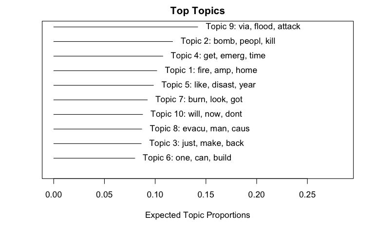

```r
plot(mod, type = "summary")
```

This S3 method in the `stm` package gives you something to start with, but best practice is to label the topics with the names you have chosen to describe them.

Another way to use the topic model is to show topic correlations. This is a measure of what topics are discussed *together* in a single document. This is a great opportunity to look for qualitative evidence consistent with a theoretical framework or a descriptive expectation, but remember, since you can’t specify ahead of time what the topics are going to be, it’s risky to design research expecting that you will have a model with useful topics that reflect particular concepts of interest.

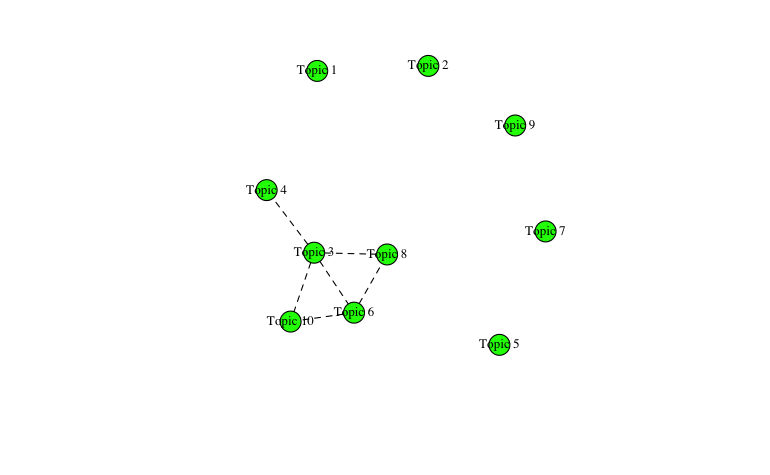

This plotting method shows us a graph where topics (nodes) are connected by a dashed line (edge) if they are positively correlated with a correlation coefficient > 0.05. We can interpret this to say, for example, that documents talking about explosions are not likely to be talking about computers, since no edge links topic 2 and topic 10. This makes sense, which is a good sign!

One thing the STM package does not natively support is visualizing negative topic correlations. For some research questions and some model fits, it can be substantively useful to know when topics are *substitutes* or negatively correlated within documents. If you want to do this you can take the output of the `topic.Corr()` function and plot it with graph visualization packages like `ggraph`, `corrviz` or `igraph`, rather than the S3 plot method.

Finally, STM supports estimation of linear models where document-level topic prevalence is the response variable. This is a cool feature, because it allows you to estimate the association between the ideas or topics included in the document with a variety of other things you may have measured at the document level (often something to do with the characteristics of the author or source). Some cool applications of topic modeling to survey responses (see Roberts et al. ([2014](https://onlinelibrary.wiley.com/doi/abs/10.1111/ajps.12103)), analyzing data from Gadarian and Albertson ([2014](https://onlinelibrary.wiley.com/doi/abs/10.1111/pops.12034))) estimate the association between an author’s treatment condition in a survey experiement and the contents (in topic prevalence terms) of the repsonses they produce. Here, we’ll do something more prosaic because we have few other available variables at the document level. We’ll just see whether our ``label" (whether the tweet is about a real disaster) is associated with the prevalence of Topic 10 (computers) and Topic 2 (explosions).

```r
target_effect <- estimateEffect(c(2, 10) ~ `tweets$target`, mod, meta = out$meta)
```

The very neat feature of this step is the uncertainty estimation. By default it calculates standard errors that propagate forward the uncertainty from the model fit (i.e. it does not treat the topic prevalences as perfectly measured). Let’s see what we got.

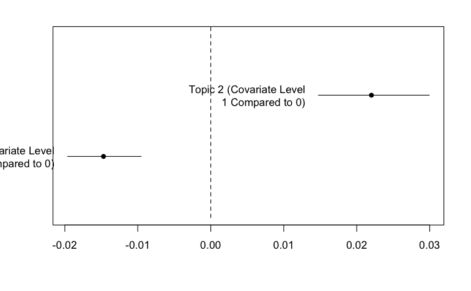

Here, we’re plotting the estimated difference in the document-level proportions of Topic 10 and Topic 2 that is associated with whether or not hte tweet is actuall about a disaster. We see that tweets that are actually about disasters have higher proportions of Topic 2, and lower proportions of Topic 10. This makes sense again. That’s good!

## Final Thoughts

There are a lot of other exciting things you can use STM to do, many of which start with specifying prevalence and content covariates in the model fit. For a content covariate, this is essentially saying: I want the vocabulary used to talk about a particular topic to vary as a function of some variable (say, party ID or treatment condition). For prevalence, this is saying: I want the estimated topic prevalence for a given topic to vary as a function of some covariate (say, time period).